# LINEAR REGRESSION AND DIAGNOSTICS IN R

Bryan McLean

January 2021

*Note: parts of this lab were taken from open-source web tutorials.*

### A bit of background…

The movie Moneyball (2011) focuses on the “quest for the secret of success in baseball”. It follows a low-budget team, the Oakland Athletics, who believed that underused statistics, such as a player’s ability to get on base, betterpredict the ability to score runs than typical statistics like home runs, RBIs (runs batted in), and batting average. Obtaining players who excelled in these underused statistics turned out to be much more affordable for the team.

In this lab we’ll be looking at data from all 30 Major League Baseball teams and examining the linear relationship between runs scored in a season and a number of other player statistics. Our aim will be to summarize these relationships both graphically and numerically in order to find which variable, if any, helps us best predict a team’s runs scored in a season.

### Load the data into R

```r
setwd("/Users/mclean/Box/UNCG_Teaching/Biostats_II/labs/1_Linear-regressions_Model-checking")
load("./data/mlb11.rdata")
# This data set contains team-wide summaries for production statistics
# There should be 30 teams and 11 statistics
```

### Examine the data

```r
# First, make sure the matrix was read into R in full:
# (i.e., that it has the dimensions we expect)
nrow(mlb11)  # number of teams
```

```
## [1] 30
```

```r
ncol(mlb11) - length(which(colnames(mlb11) == 'team'))  # number of stats
```

```
## [1] 11
```

```r
# There are several options for printing or summarizing data tables in R.
# The head() function prints the first rows of a table
head(mlb11)
```

```
##                  team runs at_bats hits homeruns bat_avg strikeouts stolen_bases wins new_onbase new_slug new_obs
## 1       Texas Rangers  855    5659 1599      210   0.283        930          143   96      0.340    0.460   0.800
## 2      Boston Red Sox  875    5710 1600      203   0.280       1108          102   90      0.349    0.461   0.810
## 3      Detroit Tigers  787    5563 1540      169   0.277       1143           49   95      0.340    0.434   0.773
## 4  Kansas City Royals  730    5672 1560      129   0.275       1006          153   71      0.329    0.415   0.744
## 5 St. Louis Cardinals  762    5532 1513      162   0.273        978           57   90      0.341    0.425   0.766
## 6       New York Mets  718    5600 1477      108   0.264       1085          130   77      0.335    0.391   0.725
```

```r
# Alternatively, we can summarize across rows and columns (R prints only several row summaries by default)
summary(mlb11)
```

```
##                    team         runs          at_bats          hits         homeruns        bat_avg         strikeouts
##  Arizona Diamondbacks: 1   Min.   :556.0   Min.   :5417   Min.   :1263   Min.   : 91.0   Min.   :0.2330   Min.   : 930
##  Atlanta Braves      : 1   1st Qu.:629.0   1st Qu.:5448   1st Qu.:1348   1st Qu.:118.0   1st Qu.:0.2447   1st Qu.:1085
##  Baltimore Orioles   : 1   Median :705.5   Median :5516   Median :1394   Median :154.0   Median :0.2530   Median :1140
##  Boston Red Sox      : 1   Mean   :693.6   Mean   :5524   Mean   :1409   Mean   :151.7   Mean   :0.2549   Mean   :1150
##  Chicago Cubs        : 1   3rd Qu.:734.0   3rd Qu.:5575   3rd Qu.:1441   3rd Qu.:172.8   3rd Qu.:0.2602   3rd Qu.:1248
##  Chicago White Sox   : 1   Max.   :875.0   Max.   :5710   Max.   :1600   Max.   :222.0   Max.   :0.2830   Max.   :1323
##  (Other)             :24
##   stolen_bases         wins          new_onbase        new_slug         new_obs
##  Min.   : 49.00   Min.   : 56.00   Min.   :0.2920   Min.   :0.3480   Min.   :0.6400
##  1st Qu.: 89.75   1st Qu.: 72.00   1st Qu.:0.3110   1st Qu.:0.3770   1st Qu.:0.6920
##  Median :107.00   Median : 80.00   Median :0.3185   Median :0.3985   Median :0.7160
##  Mean   :109.30   Mean   : 80.97   Mean   :0.3205   Mean   :0.3988   Mean   :0.7191
##  3rd Qu.:130.75   3rd Qu.: 90.00   3rd Qu.:0.3282   3rd Qu.:0.4130   3rd Qu.:0.7382
##  Max.   :170.00   Max.   :102.00   Max.   :0.3490   Max.   :0.4610   Max.   :0.8100
##
```

In addition to runs scored, there are seven traditionally used variables in the data set: at-bats, hits, home runs, batting average, strikeouts, stolen bases, and wins. There are also three newer variables: on-base percentage, slugging percentage, and on-base plus slugging.

**As a baseball manager**, one way to maximize number of runs scored could be to just increase the number of at-bats. Lets plot this relationship to explore whether more at-bats might lead to more runs scored (using the variable at_bats as the predictor, i.e., the independent variable). Does the relationship look linear?

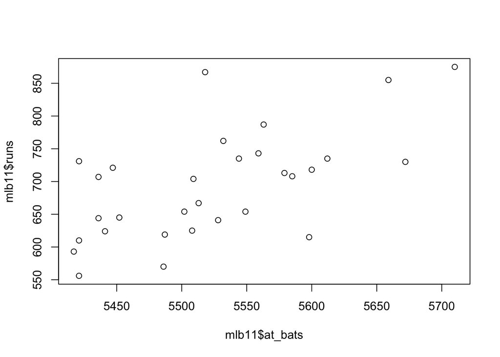

```r
plot(mlb11$at_bats, mlb11$runs)
```

### Run a Formal Linear Model

The relationship above appears linear, but we can test that using a simple linear regression between the two variables.

R’s standard linear regression function is lm(). Calls take the form y ~ x, with an optional second argument specifying the data frame that R should look in to find the model variables.

```r
m1 <- lm(runs ~ at_bats, data = mlb11)
```

The output of lm() is an object that contains all of the information we need about the linear model we just fit. We can quickly access key information using the summary() function.

```r
summary(m1)
```

```
##
## Call:
## lm(formula = runs ~ at_bats, data = mlb11)
##
## Residuals:
##     Min      1Q  Median      3Q     Max
## -125.58  -47.05  -16.59   54.40  176.87
##
## Coefficients:
##               Estimate Std. Error t value Pr(>|t|)
## (Intercept) -2789.2429   853.6957  -3.267 0.002871 **
## at_bats         0.6305     0.1545   4.080 0.000339 ***
## ---
## Signif. codes:  0 '***' 0.001 '**' 0.01 '*' 0.05 '.' 0.1 ' ' 1
##
## Residual standard error: 66.47 on 28 degrees of freedom
## Multiple R-squared:  0.3729, Adjusted R-squared:  0.3505
## F-statistic: 16.65 on 1 and 28 DF,  p-value: 0.0003388
```

Let’s consider the model summary piece by piece.

**1)** First, the formula you called to set up the model is shown at the top.

**2)** After the formula is the five-number summary of the residuals. We’ll examine this in more detail later.

**3)** The “coefficients” table is shown next. This type of table is a common part of many modeling outputs in R. Its first row displays the y-intercept for the model. Its second row contains the coefficients of at_bats. With this information so far, we can write down the least squares regression line for the entire linear model:

*ŷ =−2789.242 9 +0.6305∗atbat*

**4)** Another component of the model summary we are typically interested in is the multiple R-squared, or more simply, R2. The R2 value represents the proportion of variability in the response variable that is explained by the explanatory variable. For this model, 37.3% of the variability in runs is explained by at-bats. The adjusted R2 value is a modification of the multiple R2 (we’ll also come back to that later).

**5)** One final important component of the model summary is the statistical significance. Remember that the significance level of each model variable (rows in the table) is printed at the end of the rows. The significance of the ENTIRE model is printed on the bottom row of the summary table (showing that this simple model is highly significant).

In this model, since our sole predictor (at_bats) was significant, its no surprise that the entire model is also significant at the alpha = 0.05 level.

## MODEL DIAGNOSTICS

To assess whether any linear model is reliable, one needs to check the following assumptions to make sure they hold:

**(1)** linearity (relationship between X and the mean of Y is linear) **(2)** constant variability, or homoscedasticity (variance of Y is the same for any value of X) **(3)** normality (distribution of Y is normal at any value of X)

We already have reason to think that (1) is true, as our model summary above confirms that number of at bats (“at_bats”) is strongly predictive of number of runs (“runs”).

However, far from all of the variation in “runs” is explained by “at_bats” (check the R2 values above again). R’s linear model object contains lots of other information about this residual variation (i.e., that variation not explained by at_bats), exploring the structure of which is important for model diagnostics.

### Visualizing residual variation

To begin, explore features of our model using the attributes() function (tip: this is useful for exploring all kinds of R objects!).

```r
attributes(m1)
```

```
## $names
##  [1] "coefficients"  "residuals"     "effects"       "rank"          "fitted.values" "assign"        "qr"
##  [8] "df.residual"   "xlevels"       "call"          "terms"         "model"
##
## $class
## [1] "lm"
```

Prior to anything more detailed, it is often instructive to create a simple plot just to help visualize differences between the model predictions and the actual values (i.e., to visualize the RESIDUAL variation). To do this, we can make use of the “fitted_values” and “residuals” attributes of the model.

Also, we can make use of the handy abline() function to plot the least-squares (i.e., best-fit) line.

Im also going to plot some line segments that connect the actual and predicted (fitted) values using the segments() function.

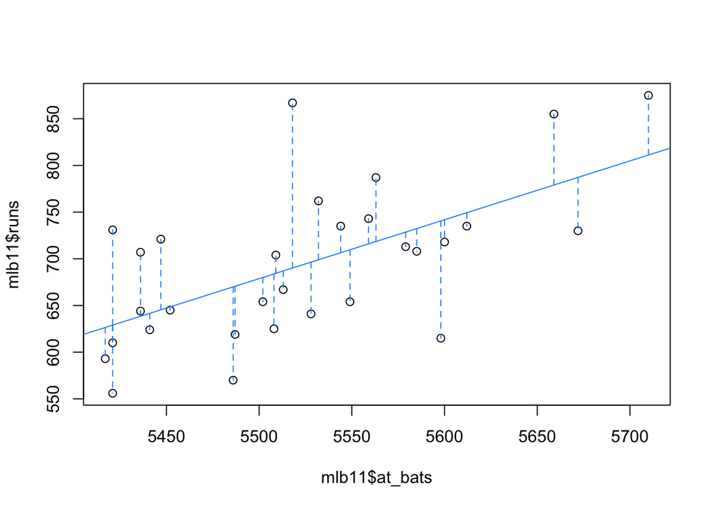

```r
plot(mlb11$at_bats, mlb11$runs)
abline(m1, col = "dodgerblue")      # plotting the model
segments(
  mlb11$at_bats,         # X values
  m1$fitted.values,      # predicted Y values
  mlb11$at_bats,         # X values
  mlb11$runs,            # real Y values
  col = 'dodgerblue',
  lty = 2
  )
```

### Tests of linearity and homoscedasticity

Two additional plots allow us to check assumptions (1) and (2) listed above.

The first is a plot of residuals versus predicted values. If the data don’t meet the linearity assumption, we would expect to see residuals that are very large (big positive or negative values). What we want to see is residuals centered on 0 (standardized values less than -2 or greater than 2 are deemed problematic). This plot also allows us to test the homoscedasticity assumption. What we want to see is no pattern in residuals along different values of X; there should be a constant level of variation around the Y = 0 line.

The second plot below is just a histogram of the residuals themselves, which is also useful for testing homoscedasticity.

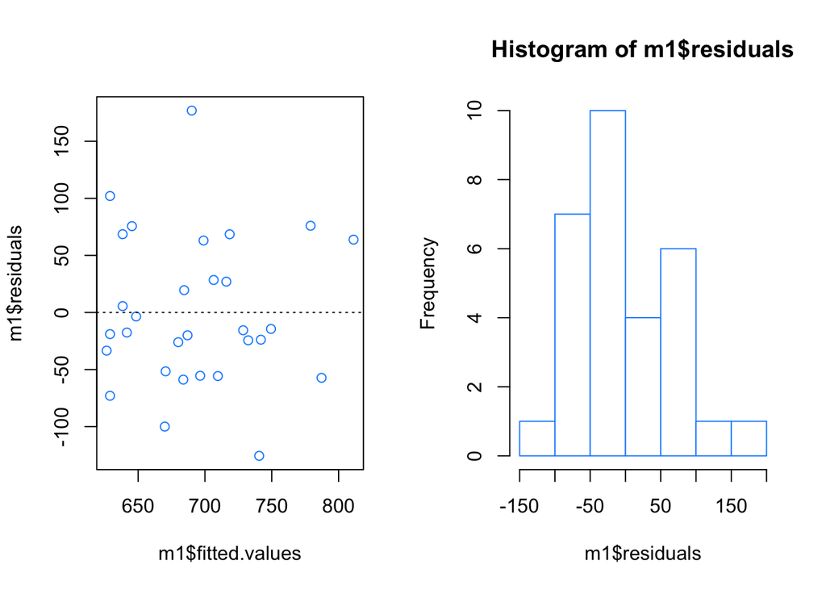

```r
par(mfrow = c(1,2))
plot(m1 $residuals ~ m1$fitted.values, col = 'dodgerblue')  # plot of residuals vs. fitted
abline(h = 0, lty = 3)  # add a horizontal dashed line at y = 0
hist(m1$residuals, col = 'white', border = 'dodgerblue')  # histogram of residuals
```

### Tests of normality

The final assumption of our linear model is normality (#3 above), and it is evaluated based on the residuals using a QQ-plot. This plot compares the residuals to “ideal” normal observations. Observations lying along the 1:1 line in the QQ-plot indicate that the normality assumption holds. (Note: the plot() function applied to a model object generates a series of diagnostic plots, so we can just choose the second of these.)

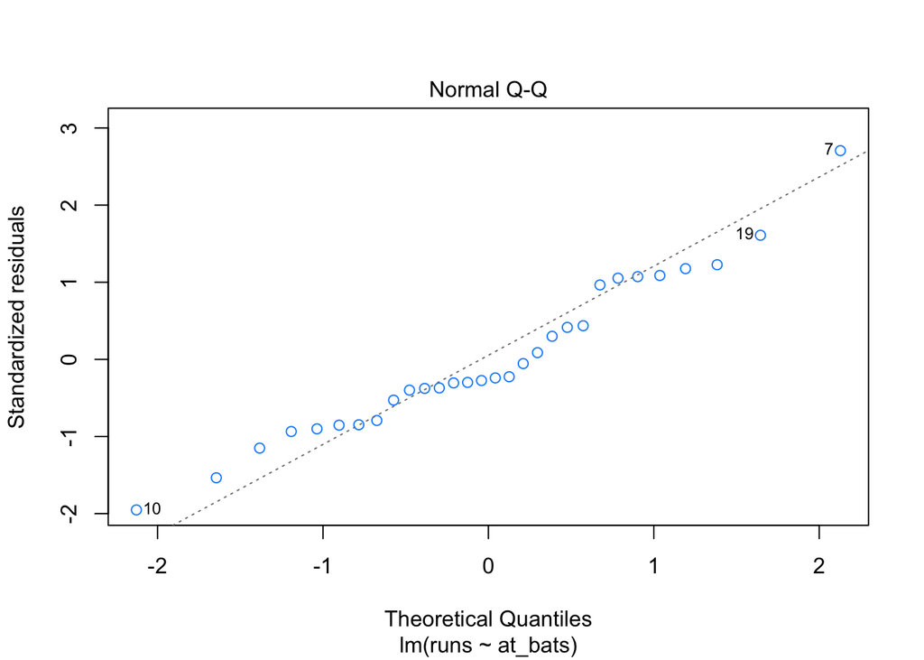

```r
par(mfrow = c(1,1))
plot(m1, which = 2, col = 'dodgerblue')  # the q-q plot
```

## THIS WEEK’S ASSIGNMENT

At this point, you should be familiar with the syntax and workflow necessary to set up a simple, BIVARIATE linear model in R using data stored in R’s memory. You should also be familiar with performing basic diagnostics on your model to make sure it meets THREE major assumptions of LINEARITY, CONSTANT VARIABILITY (homoscedasticity), and NORMALITY.

**Your assignment for this portion of the lab is to construct a bivariate linear model for the relationship between at_bats (independent) and strikeouts (dependent).** You previously found that more at_bats lead to more runs scored (a good thing), but it is reasonable to think that more at_bats also results in more striekouts (a bad thing).